# **Flight Booking Prediction**

**Business Context**

An aviation company offering both domestic and international travel services aims to improve its customer acquisition strategy in an increasingly competitive digital marketing environment. Traditionally, the company has relied on broad-based outreach methods such as telecalling and generic advertisements. However, these approaches are costly, less targeted, and yield low conversion rates.

Industry benchmarks indicate that average digital marketing conversion rates typically range between 2% and 5%, and in the travel and aviation sector, conversion rates are often lower due to high competition, multiple alternatives, and price-sensitive customers. This means that a large proportion of marketing expenditure is spent on users who do not eventually purchase tickets.

To address this challenge, the company has partnered with a social networking platform to leverage customer digital behavior and social engagement data for targeted advertising. Since digital advertising platforms charge based on impressions, clicks, or engagement, untargeted campaigns significantly increase customer acquisition costs. Therefore, it has become essential for the company to focus its marketing efforts only on customers who are most likely to convert, thereby improving conversion efficiency and return on investment.

**Objective of the Project**

As a data scientist, the objective is to build predictive classification models that estimate the propensity of customers to purchase airline tickets based on their online behavior and engagement patterns available in the dataset. Given that device usage strongly influences browsing and purchasing behavior, two separate predictive models are developed:

1. One for laptop users
2. One for mobile users

These models aim to identify high-probability customers who are more likely to purchase tickets, enabling the company to: Reduce unnecessary digital advertising spend Improve effective conversion rates Run more efficient and personalized marketing campaigns Accurate prediction models will help the company maximize conversions while minimizing marketing costs, ultimately leading to improved business performance and profitability.

**Data Description:**

The dataset contains different attributes for potential customers of the aviation company. The detailed data dictionary is given below:

**UserID:** Unique ID of user

**Buy_ticket:** Buy a ticket next month

**Yearly_avg_view_on_travel_page:** Average yearly views on any travel-related page by user

**preferred_device:** Through which device user prefer to do login

**total_likes_on_outstation_checkin_given:** Total number of likes given by a user on out-of-station check-ins in the last year

**yearly_avg_Outstation_checkins:** Average number of out-of-station check-ins done by the user

**member_in_family:** Total number of relationships mentioned by the user in the account

**preferred_location_type:** Preferred type of location for travelling of user

**Yearly_avg_comment_on_travel_page:** Average yearly comments on any travel-related page by user

**total_likes_on_outofstation_checkin_received:** Total number of likes received by a user on out-of-station check-ins in the last year

**week_since_last_outstation_checkin:** Number of weeks since last out-of-station check-in update by user

**following_company_page:** Whether the customer is following the company page (Yes or No)

**montly_avg_comment_on_company_page:** Average monthly comments on the company page by user

**working_flag:** Whether the customer is working or not

**travelling_network_rating:** Does the user have close friends who also like travelling? 1 is high and 4 is lowest

**Adult_flag:** Whether the customer is an adult or not

**Daily_Avg_mins_spend_on_traveling_page:** Average time spent on the company page by user on a daily basis.

**Relevance of Conversion Rate to This Project**

The dataset used in this project contains customer demographic details, device preferences, and digital behavior indicators, along with a target variable representing whether a customer purchased an airline ticket or not. Since only a small proportion of digitally engaged users actually convert into buyers, predicting purchase likelihood becomes critical. By identifying customers who are more likely to convert, the company can improve its effective conversion rate without increasing marketing spend.

**Scope of the Project**

The scope of this project is limited to analyzing the provided customer dataset to identify patterns in digital behavior and predict ticket purchase propensity. The study includes exploratory data analysis, data preprocessing, and development of classification models for mobile and laptop users. Model performance is evaluated using standard classification metrics.

**Beneficiaries of the Project**

This project benefits multiple stakeholders:

1. Business / Aviation Company: Reduced marketing expenditure, improved conversion rates, and better return on investment by targeting only high-probability customers.
2. Marketing Teams: Data-driven insights that help design focused and personalized digital campaigns instead of mass marketing.
3. Customers: Improved user experience by receiving relevant and personalized advertisements rather than generic promotional messages.

**Significance of the Project**

This project helps the aviation company move from broad-based marketing to data-driven targeted advertising. By identifying high-probability customers, the company can optimize marketing spend, improve conversion efficiency, and enhance customer experience. The study also demonstrates the practical application of machine learning in solving real-world digital marketing challenges.

## **Importing the required packages**

```python
#libraries to read and manipulate data
import numpy as np
import pandas as pd

#libraries to visualize data
import matplotlib.pyplot as plt
import seaborn as sns
import statsmodels.api as sm
from sklearn.model_selection import train_test_split
from sklearn.preprocessing import StandardScaler
from sklearn.metrics import accuracy_score, classification_report, confusion_matrix, ConfusionMatrixDisplay
from sklearn.linear_model import LogisticRegression
from sklearn.tree import DecisionTreeClassifier
from sklearn.ensemble import RandomForestClassifier, BaggingClassifier, AdaBoostClassifier, GradientBoostingClassifier
from sklearn.metrics import accuracy_score, precision_score, recall_score, f1_score
from sklearn.metrics import classification_report, roc_auc_score
from sklearn.metrics import make_scorer
from sklearn.model_selection import GridSearchCV
from xgboost import XGBClassifier
```

## **Loading the Dataset**

```python
df = pd.read_excel('/content/flight_customer_data.xlsx')
```

```python
df
```

|  | UserID | Taken_product | Yearly_avg_view_on_travel_page | preferred_device | total_likes_on_outstation_checkin_given | yearly_avg_Outstation_checkins | member_in_family | preferred_location_type | Yearly_avg_comment_on_travel_page | total_likes_on_outofstation_checkin_received | week_since_last_outstation_checkin | following_company_page | montly_avg_comment_on_company_page | working_flag | travelling_network_rating | Adult_flag | Daily_Avg_mins_spend_on_traveling_page |
| --- | --- | --- | --- | --- | --- | --- | --- | --- | --- | --- | --- | --- | --- | --- | --- | --- | --- |
| 0 | 1000001 | Yes | 307.0 | iOS and Android | 38570.0 | 1 | 2 | Financial | 94.0 | 5993 | 8 | Yes | 11 | No | 1 | 0 | 8 |
| 1 | 1000002 | No | 367.0 | iOS | 9765.0 | 1 | 1 | Financial | 61.0 | 5130 | 1 | No | 23 | Yes | 4 | 1 | 10 |
| 2 | 1000003 | Yes | 277.0 | iOS and Android | 48055.0 | 1 | 2 | Other | 92.0 | 2090 | 6 | Yes | 15 | No | 2 | 0 | 7 |
| 3 | 1000004 | No | 247.0 | iOS | 48720.0 | 1 | 4 | Financial | 56.0 | 2909 | 1 | Yes | 11 | No | 3 | 0 | 8 |
| 4 | 1000005 | No | 202.0 | iOS and Android | 20685.0 | 1 | 1 | Medical | 40.0 | 3468 | 9 | No | 12 | No | 4 | 1 | 6 |
| ... | ... | ... | ... | ... | ... | ... | ... | ... | ... | ... | ... | ... | ... | ... | ... | ... | ... |
| 11755 | 1011756 | No | 279.0 | Laptop | 30987.0 | 23 | 2 | Historical site | 58.0 | 2616 | 4 | No | 36 | No | 3 | 1 | 23 |
| 11756 | 1011757 | No | 305.0 | Tab | 21510.0 | 6 | 1 | Historical site | 55.0 | 10041 | 4 | No | 30 | No | 1 | 1 | 11 |
| 11757 | 1011758 | No | 214.0 | Tab | 5478.0 | 4 | 3 | Beach | 103.0 | 6203 | 3 | Yes | 40 | Yes | 2 | 1 | 12 |
| 11758 | 1011759 | No | 382.0 | Laptop | 35851.0 | 2 | 3 | Historical site | 83.0 | 5444 | 3 | No | 32 | No | 4 | 0 | 20 |
| 11759 | 1011760 | No | 270.0 | Tab | 22025.0 | 8 | 3 | Historical site | 104.0 | 4470 | 2 | No | 29 | No | 1 | 0 | 14 |

11760 rows × 17 columns

## **Data Overview**

### **View the first and last 5 rows of the dataset**

```python
df.head()
```

|  | UserID | Taken_product | Yearly_avg_view_on_travel_page | preferred_device | total_likes_on_outstation_checkin_given | yearly_avg_Outstation_checkins | member_in_family | preferred_location_type | Yearly_avg_comment_on_travel_page | total_likes_on_outofstation_checkin_received | week_since_last_outstation_checkin | following_company_page | montly_avg_comment_on_company_page | working_flag | travelling_network_rating | Adult_flag | Daily_Avg_mins_spend_on_traveling_page |
| --- | --- | --- | --- | --- | --- | --- | --- | --- | --- | --- | --- | --- | --- | --- | --- | --- | --- |
| 0 | 1000001 | Yes | 307.0 | iOS and Android | 38570.0 | 1 | 2 | Financial | 94.0 | 5993 | 8 | Yes | 11 | No | 1 | 0 | 8 |
| 1 | 1000002 | No | 367.0 | iOS | 9765.0 | 1 | 1 | Financial | 61.0 | 5130 | 1 | No | 23 | Yes | 4 | 1 | 10 |
| 2 | 1000003 | Yes | 277.0 | iOS and Android | 48055.0 | 1 | 2 | Other | 92.0 | 2090 | 6 | Yes | 15 | No | 2 | 0 | 7 |
| 3 | 1000004 | No | 247.0 | iOS | 48720.0 | 1 | 4 | Financial | 56.0 | 2909 | 1 | Yes | 11 | No | 3 | 0 | 8 |
| 4 | 1000005 | No | 202.0 | iOS and Android | 20685.0 | 1 | 1 | Medical | 40.0 | 3468 | 9 | No | 12 | No | 4 | 1 | 6 |

```python
df.tail()
```

|  | UserID | Taken_product | Yearly_avg_view_on_travel_page | preferred_device | total_likes_on_outstation_checkin_given | yearly_avg_Outstation_checkins | member_in_family | preferred_location_type | Yearly_avg_comment_on_travel_page | total_likes_on_outofstation_checkin_received | week_since_last_outstation_checkin | following_company_page | montly_avg_comment_on_company_page | working_flag | travelling_network_rating | Adult_flag | Daily_Avg_mins_spend_on_traveling_page |
| --- | --- | --- | --- | --- | --- | --- | --- | --- | --- | --- | --- | --- | --- | --- | --- | --- | --- |
| 11755 | 1011756 | No | 279.0 | Laptop | 30987.0 | 23 | 2 | Historical site | 58.0 | 2616 | 4 | No | 36 | No | 3 | 1 | 23 |
| 11756 | 1011757 | No | 305.0 | Tab | 21510.0 | 6 | 1 | Historical site | 55.0 | 10041 | 4 | No | 30 | No | 1 | 1 | 11 |
| 11757 | 1011758 | No | 214.0 | Tab | 5478.0 | 4 | 3 | Beach | 103.0 | 6203 | 3 | Yes | 40 | Yes | 2 | 1 | 12 |
| 11758 | 1011759 | No | 382.0 | Laptop | 35851.0 | 2 | 3 | Historical site | 83.0 | 5444 | 3 | No | 32 | No | 4 | 0 | 20 |
| 11759 | 1011760 | No | 270.0 | Tab | 22025.0 | 8 | 3 | Historical site | 104.0 | 4470 | 2 | No | 29 | No | 1 | 0 | 14 |

### **Understand the shape of the dataset**

```python
df.shape
```

```
(11760, 17)
```

**Observation:**

- There are 11760 observations and 17 columns in the dataset

### **Checking the data types of the columns for the dataset**

```python
df.info()
```

```
<class 'pandas.core.frame.DataFrame'>
RangeIndex: 11760 entries, 0 to 11759
Data columns (total 17 columns):
 #   Column                                        Non-Null Count  Dtype
---  ------                                        --------------  -----
 0   UserID                                        11760 non-null  int64
 1   Taken_product                                 11760 non-null  object
 2   Yearly_avg_view_on_travel_page                11179 non-null  float64
 3   preferred_device                              11707 non-null  object
 4   total_likes_on_outstation_checkin_given       11379 non-null  float64
 5   yearly_avg_Outstation_checkins                11685 non-null  object
 6   member_in_family                              11760 non-null  object
 7   preferred_location_type                       11729 non-null  object
 8   Yearly_avg_comment_on_travel_page             11554 non-null  float64
 9   total_likes_on_outofstation_checkin_received  11760 non-null  int64
 10  week_since_last_outstation_checkin            11760 non-null  int64
 11  following_company_page                        11657 non-null  object
 12  montly_avg_comment_on_company_page            11760 non-null  int64
 13  working_flag                                  11760 non-null  object
 14  travelling_network_rating                     11760 non-null  int64
 15  Adult_flag                                    11760 non-null  int64
 16  Daily_Avg_mins_spend_on_traveling_page        11760 non-null  int64
dtypes: float64(3), int64(7), object(7)
memory usage: 1.5+ MB
```

**Observations:**

- There are 17 columns
  - 7 of these columns are integer datatypes.
  - 7 of them being objects.
  - 3 of them being a float.
- There are some missing values in few columns in the dataset which need to be treated.

### **Checking for duplicates values**

```python
# checking for duplicate values
df.duplicated().sum()
```

```
np.int64(0)
```

**Observations:**

- There are no duplicate rows present in the dataset.

### **Checking the missing values**

```python
# checking for missing values
df.isnull().sum()
```

|  | 0 |
| --- | --- |
| UserID | 0 |
| Taken_product | 0 |
| Yearly_avg_view_on_travel_page | 581 |
| preferred_device | 53 |
| total_likes_on_outstation_checkin_given | 381 |
| yearly_avg_Outstation_checkins | 75 |
| member_in_family | 0 |
| preferred_location_type | 31 |
| Yearly_avg_comment_on_travel_page | 206 |
| total_likes_on_outofstation_checkin_received | 0 |
| week_since_last_outstation_checkin | 0 |
| following_company_page | 103 |
| montly_avg_comment_on_company_page | 0 |
| working_flag | 0 |
| travelling_network_rating | 0 |
| Adult_flag | 0 |
| Daily_Avg_mins_spend_on_traveling_page | 0 |

**dtype:** int64

**Observations:**

- Yearly_avg_view_on_travel_page, preferred_device, total_likes_on_outstation_checkin_given, yearly_avg_Outstation_checkins, preferred_location_type, Yearly_avg_comment_on_travel_page and following_company_page have missing values in them.
- There are no missing values in other columns.

#### **Handle numerical missing values**

```python
num_cols = [
    'Yearly_avg_view_on_travel_page',
    'total_likes_on_outstation_checkin_given',
    'yearly_avg_Outstation_checkins',
    'Yearly_avg_comment_on_travel_page'
]

df['yearly_avg_Outstation_checkins'] = df['yearly_avg_Outstation_checkins'].replace('*', np.nan)
df['yearly_avg_Outstation_checkins'] = pd.to_numeric(df['yearly_avg_Outstation_checkins'])

for col in num_cols:
    df[col] = df[col].fillna(df[col].median())
```

```python
df.isnull().sum()
```

|  | 0 |
| --- | --- |
| UserID | 0 |
| Taken_product | 0 |
| Yearly_avg_view_on_travel_page | 0 |
| preferred_device | 53 |
| total_likes_on_outstation_checkin_given | 0 |
| yearly_avg_Outstation_checkins | 0 |
| member_in_family | 0 |
| preferred_location_type | 31 |
| Yearly_avg_comment_on_travel_page | 0 |
| total_likes_on_outofstation_checkin_received | 0 |
| week_since_last_outstation_checkin | 0 |
| following_company_page | 103 |
| montly_avg_comment_on_company_page | 0 |
| working_flag | 0 |
| travelling_network_rating | 0 |
| Adult_flag | 0 |
| Daily_Avg_mins_spend_on_traveling_page | 0 |

**dtype:** int64

#### **Handle categorical missing values**

```python
cat_cols = [
    'preferred_device',
    'preferred_location_type',
    'following_company_page'
]

for col in cat_cols:
    df[col] = df[col].fillna(df[col].mode()[0])
```

```python
df.isnull().sum()
```

|  | 0 |
| --- | --- |
| UserID | 0 |
| Taken_product | 0 |
| Yearly_avg_view_on_travel_page | 0 |
| preferred_device | 0 |
| total_likes_on_outstation_checkin_given | 0 |
| yearly_avg_Outstation_checkins | 0 |
| member_in_family | 0 |
| preferred_location_type | 0 |
| Yearly_avg_comment_on_travel_page | 0 |
| total_likes_on_outofstation_checkin_received | 0 |
| week_since_last_outstation_checkin | 0 |
| following_company_page | 0 |
| montly_avg_comment_on_company_page | 0 |
| working_flag | 0 |
| travelling_network_rating | 0 |
| Adult_flag | 0 |
| Daily_Avg_mins_spend_on_traveling_page | 0 |

**dtype:** int64

**Note:**

Median imputation was used for numerical variables to handle skewness, while mode imputation was applied for categorical variables.

### **Getting the statistical summary for the dataset**

```python
df.describe(include='all').T
# setting include='all' will get the statistical summary for both the numerical and categorical variables.
```

|  | count | unique | top | freq | mean | std | min | 25% | 50% | 75% | max |
| --- | --- | --- | --- | --- | --- | --- | --- | --- | --- | --- | --- |
| UserID | 11760.0 | NaN | NaN | NaN | 1005880.5 | 3394.963917 | 1000001.0 | 1002940.75 | 1005880.5 | 1008820.25 | 1011760.0 |
| Taken_product | 11760 | 2 | No | 9864 | NaN | NaN | NaN | NaN | NaN | NaN | NaN |
| Yearly_avg_view_on_travel_page | 11760.0 | NaN | NaN | NaN | 280.345153 | 66.51133 | 35.0 | 233.0 | 271.0 | 322.0 | 464.0 |
| preferred_device | 11760 | 10 | Tab | 4225 | NaN | NaN | NaN | NaN | NaN | NaN | NaN |
| total_likes_on_outstation_checkin_given | 11760.0 | NaN | NaN | NaN | 28167.420748 | 14150.080463 | 3570.0 | 16697.25 | 28076.0 | 40115.25 | 252430.0 |
| yearly_avg_Outstation_checkins | 11760.0 | NaN | NaN | NaN | 8.196259 | 8.65095 | 1.0 | 1.0 | 4.0 | 14.0 | 29.0 |
| member_in_family | 11760.0 | 7.0 | 3.0 | 4561.0 | NaN | NaN | NaN | NaN | NaN | NaN | NaN |
| preferred_location_type | 11760 | 15 | Beach | 2455 | NaN | NaN | NaN | NaN | NaN | NaN | NaN |
| Yearly_avg_comment_on_travel_page | 11760.0 | NaN | NaN | NaN | 74.793707 | 23.81528 | 3.0 | 57.0 | 75.0 | 92.0 | 815.0 |
| total_likes_on_outofstation_checkin_received | 11760.0 | NaN | NaN | NaN | 6531.699065 | 4706.613785 | 1009.0 | 2940.75 | 4948.0 | 8393.25 | 20065.0 |
| week_since_last_outstation_checkin | 11760.0 | NaN | NaN | NaN | 3.203571 | 2.616365 | 0.0 | 1.0 | 3.0 | 5.0 | 11.0 |
| following_company_page | 11760 | 4 | No | 8458 | NaN | NaN | NaN | NaN | NaN | NaN | NaN |
| montly_avg_comment_on_company_page | 11760.0 | NaN | NaN | NaN | 28.661565 | 48.660504 | 11.0 | 17.0 | 22.0 | 27.0 | 500.0 |
| working_flag | 11760 | 2 | No | 9952 | NaN | NaN | NaN | NaN | NaN | NaN | NaN |
| travelling_network_rating | 11760.0 | NaN | NaN | NaN | 2.712245 | 1.080887 | 1.0 | 2.0 | 3.0 | 4.0 | 4.0 |
| Adult_flag | 11760.0 | NaN | NaN | NaN | 0.793878 | 0.851823 | 0.0 | 0.0 | 1.0 | 1.0 | 3.0 |
| Daily_Avg_mins_spend_on_traveling_page | 11760.0 | NaN | NaN | NaN | 13.817432 | 9.070657 | 0.0 | 8.0 | 12.0 | 18.0 | 270.0 |

**Observations:**

- The dataset has around 11,760 records, with a few columns containing missing values.
- Most users have not taken the product, showing low conversion.
- Beach is the most preferred travel location among users.
- Tab is the most commonly used device for browsing travel pages.
- User engagement (likes and comments) shows high variation, indicating the presence of outliers.
- Most users belong to small families with around 3 members.
- Users spend on average about 12 minutes per day on travel pages.
- A small group of users is highly active, contributing to very high maximum values in engagement

## **DEVICE-WISE SEGREGATION**

### **Identify Variable Types**

```python
categorical_cols = df.select_dtypes(include=['object']).columns
numerical_cols = df.select_dtypes(include=['int64','float64']).columns

categorical_cols, numerical_cols
```

```
(Index(['Taken_product', 'preferred_device', 'member_in_family',
        'preferred_location_type', 'following_company_page', 'working_flag'],
       dtype='object'),
 Index(['UserID', 'Yearly_avg_view_on_travel_page',
        'total_likes_on_outstation_checkin_given',
        'yearly_avg_Outstation_checkins', 'Yearly_avg_comment_on_travel_page',
        'total_likes_on_outofstation_checkin_received',
        'week_since_last_outstation_checkin',
        'montly_avg_comment_on_company_page', 'travelling_network_rating',
        'Adult_flag', 'Daily_Avg_mins_spend_on_traveling_page'],
       dtype='object'))
```

UserId, Adult_flag, network_flag, product_taken are discrete numerics treated as categorical

### **Encoding Taken_product and following_company_page column in binary values**

```python
df['Taken_product'] = df['Taken_product'].map({'Yes':1, 'No':0})
df['following_company_page'] = df['following_company_page'].map({'Yes':1, 'No': 0, 1:1, 0:0})
```

### **Replacing the duplicate values in the preferred_device column**

```python
df['preferred_device'].unique()
```

```
array(['iOS and Android', 'iOS', 'ANDROID', 'Tab', 'Android',
       'Android OS', 'Other', 'Others', 'Laptop', 'Mobile'], dtype=object)
```

```python
def map_device(x):
    x = str(x).lower().strip()
    if x in ['mobile', 'ios', 'android', 'ios and android']:
        return 'Mobile'
    elif x in ['laptop', 'tab']:
        return 'Laptop'
    else:
        return 'Other'

df['device_group'] = df['preferred_device'].apply(map_device)
```

```python
df['device_group'].value_counts()
```

| device_group | count |
| --- | --- |
| Mobile | 6278 |
| Laptop | 5333 |
| Other | 149 |

**dtype:** int64

```python
## copying the dataset to another variable
df_full = df.copy()

# Device comparison dataset (only Mobile & Laptop)
df_device = df[df['device_group'].isin(['Mobile', 'Laptop'])]

df_mobile = df_device[df_device['device_group'] == 'Mobile']
df_laptop = df_device[df_device['device_group'] == 'Laptop']
```

**Note:**

After cleaning, the dataset consisted of 6,278 mobile users, 5,333 laptop users, 149 users under other devices. Due to the very small size of the “Other” category, it was excluded from further analysis.

## **Exploratory Data Analysis**

### **Univariate Analysis**

#### **Daily Avg Minutes Spent On Travelling Page vs Booking For Mobile**

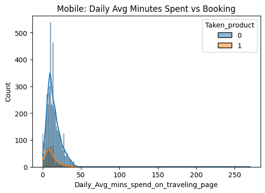

```python
plt.figure(figsize=(6,4))
sns.histplot(
    data=df_mobile,
    x='Daily_Avg_mins_spend_on_traveling_page',
    hue='Taken_product',
    kde=True
)
plt.title("Mobile: Daily Avg Minutes Spent vs Booking")
plt.show()
```

**Observations:**

1. Most non-booked mobile users spend more time on the traveling page.
2. Booked users usually spend less time and make quicker decisions.
3. The distribution is right-skewed, especially for non-booked users.
4. Higher time spent on mobile does not guarantee booking.
5. Longer sessions likely indicate browsing or confusion rather than intent.

#### **Daily Avg Minutes Spent On Travelling Page vs Booking For Laptop**

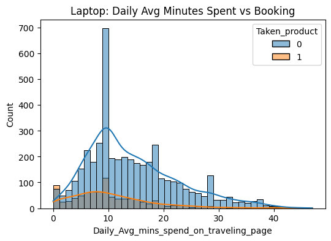

```python
plt.figure(figsize=(6,4))
sns.histplot(
    data=df_laptop,
    x='Daily_Avg_mins_spend_on_traveling_page',
    hue='Taken_product',
    kde=True
)
plt.title("Laptop: Daily Avg Minutes Spent vs Booking")
plt.show()
```

**Observations:**

1. Laptop users who did not book tend to spend more time on the traveling page.
2. Users who booked tickets generally spend less and more consistent time.
3. The distribution shows less extreme skewness compared to mobile users.
4. Longer time spent on laptop does not strongly increase booking probability.
5. Laptop users appear more focused, completing bookings in shorter sessions.

#### **Yearly Avg On :Travel Page Views vs Booking For Mobile**

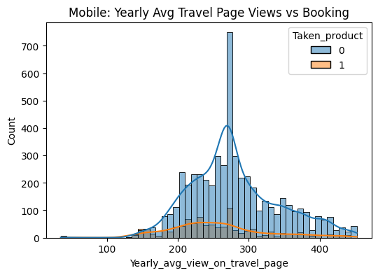

```python
plt.figure(figsize=(6,4))
sns.histplot(
    data=df_mobile,
    x='Yearly_avg_view_on_travel_page',
    hue='Taken_product',
    kde=True
)
plt.title("Mobile: Yearly Avg Travel Page Views vs Booking")
plt.show()
```

**Observations:**

1. Most mobile users with high yearly page views still do not book tickets.
2. Booked users are concentrated around moderate page views, not extremely high values.
3. The distribution is right-skewed, especially for non-booked users.
4. Higher page views on mobile do not directly lead to booking.
5. Repeated viewing likely reflects searching or comparison behavior rather than purchase intent.

#### **Yearly Avg On :Travel Page Views vs Booking For Laptop**

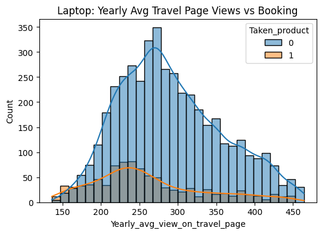

```python
plt.figure(figsize=(6,4))
sns.histplot(
    data=df_laptop,
    x='Yearly_avg_view_on_travel_page',
    hue='Taken_product',
    kde=True
)
plt.title("Laptop: Yearly Avg Travel Page Views vs Booking")
plt.show()
```

**Observations:**

1. Many laptop users view travel pages frequently but do not complete booking.
2. Booked users are mostly concentrated around moderate page view counts.
3. The distribution is less skewed compared to mobile users.
4. Extremely high page views do not strongly improve booking chances.
5. Laptop users with moderate viewing behavior show higher booking intent.

### **Bivariant Analysis**

#### **Following Company Page vs Booking For Mobile**

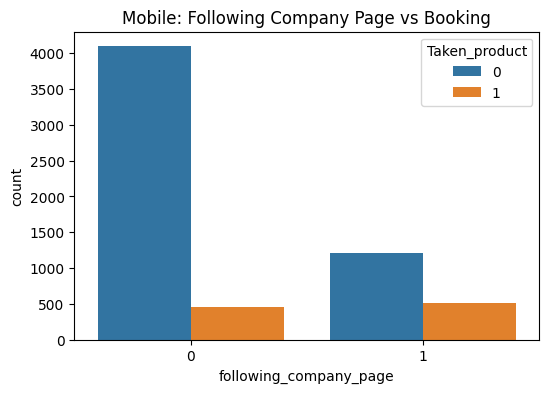

```python
plt.figure(figsize=(6,4))
sns.countplot(
    data=df_mobile,
    x='following_company_page',
    hue='Taken_product'
)
plt.title("Mobile: Following Company Page vs Booking")
plt.show()
```

**Observations:**

1. Most mobile users who do not follow the company page do not book tickets.
2. A higher proportion of bookings comes from users who follow the company page.
3. Following the company page shows a positive association with booking.
4. Non-followers have lower engagement and conversion.
5. Social media following helps improve trust and booking intent.

#### **Following Company Page vs Booking For Laptop**

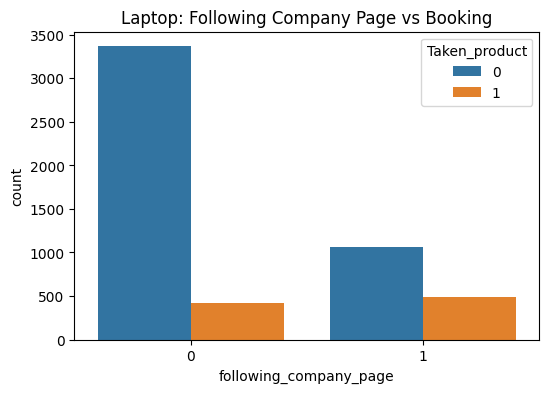

```python
plt.figure(figsize=(6,4))
sns.countplot(
    data=df_laptop,
    x='following_company_page',
    hue='Taken_product'
)
plt.title("Laptop: Following Company Page vs Booking")
plt.show()
```

**Observations:**

1. Most laptop users who do not follow the company page do not book tickets.
2. Users who follow the company page show a higher booking count.
3. Following the company page is positively associated with ticket booking.
4. Laptop users who follow the page appear more engaged and confident.
5. Social media presence helps increase trust and conversion on laptops.

#### **Preferred Location Type vs Booking For Mobile**

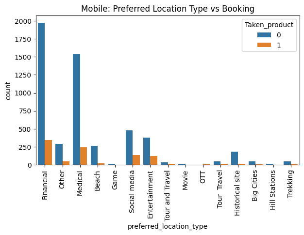

```python
plt.figure(figsize=(7,4))
sns.countplot(
    data=df_mobile,
    x='preferred_location_type',
    hue='Taken_product'
)
plt.title("Mobile: Preferred Location Type vs Booking")
plt.xticks(rotation=90)
plt.show()
```

**Observations:**

#### **Preferred Location Type vs Booking For Laptop**

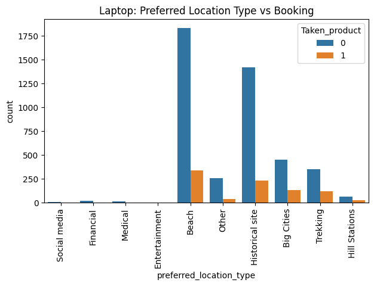

```python
plt.figure(figsize=(7,4))
sns.countplot(
    data=df_laptop,
    x='preferred_location_type',
    hue='Taken_product'
)
plt.title("Laptop: Preferred Location Type vs Booking")
plt.xticks(rotation=90)
plt.show()
```

**Observations:**

1. Most laptop users preferring Beach and Historical sites do not book tickets.
2. Bookings are relatively higher for Beach locations compared to other categories.
3. Trekking shows a more balanced pattern between booked and not booked users.
4. Big Cities and Hill Stations have lower overall booking volumes.

### **MULTIVARIATE ANALYSIS**

#### **Yearly Average Page Views vs Booking For Mobile**

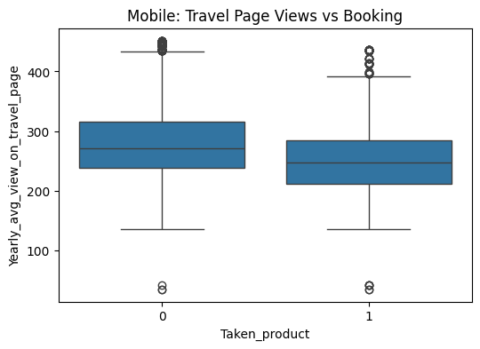

```python
plt.figure(figsize=(6,4))
sns.boxplot(
    data=df_mobile,
    x='Taken_product',
    y='Yearly_avg_view_on_travel_page'
)
plt.title("Mobile: Travel Page Views vs Booking")
plt.show()
```

**Observations:**

1. Non-booked users generally have a slightly higher median travel page views.
2. Booked users show lower median page views, indicating quicker decisions.
3. Both groups have wide spread, showing varied browsing behavior.
4. Presence of outliers suggests some users view pages excessively without booking.
5. Higher page views on mobile do not guarantee booking.

#### **Yearly Average Page Views vs Booking For Laptop**

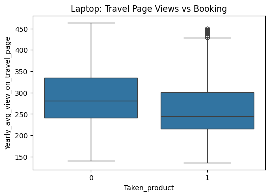

```python
plt.figure(figsize=(6,4))
sns.boxplot(
    data=df_laptop,
    x='Taken_product',
    y='Yearly_avg_view_on_travel_page'
)
plt.title("Laptop: Travel Page Views vs Booking")
plt.show()
```

**Observations:**

#### **Time Spent vs Views For Mobile**

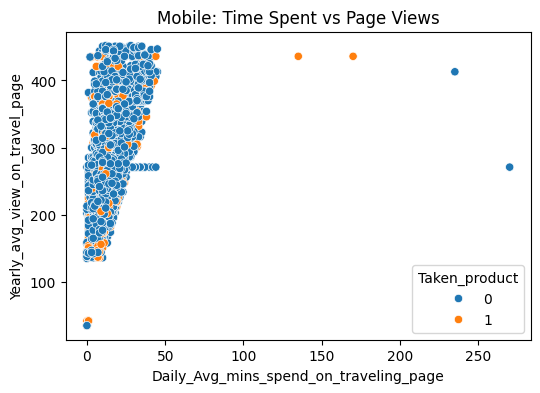

```python
plt.figure(figsize=(6,4))
sns.scatterplot(
    data=df_mobile,
    x='Daily_Avg_mins_spend_on_traveling_page',
    y='Yearly_avg_view_on_travel_page',
    hue='Taken_product'
)
plt.title("Mobile: Time Spent vs Page Views")
plt.show()
```

**Observations:**

1. Non-booked mobile users dominate the plot and are spread across both high time spent and high page views.
2. Booked users are few and mostly appear at low to moderate time spent.
3. There is a positive relationship between time spent and page views for mobile users.
4. Several users spend very high time with high page views but still do not book.
5. This indicates that on mobile, long browsing does not translate into booking.

#### **Time Spent On Travel Pages vs Views For Laptop**

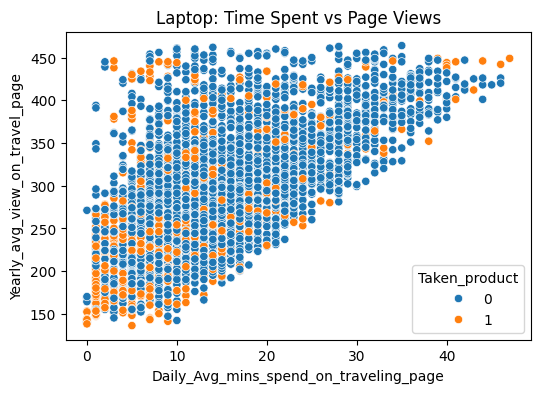

```python
plt.figure(figsize=(6,4))
sns.scatterplot(
    data=df_laptop,
    x='Daily_Avg_mins_spend_on_traveling_page',
    y='Yearly_avg_view_on_travel_page',
    hue='Taken_product'
)
plt.title("Laptop: Time Spent vs Page Views")
plt.show()
```

**Observations:**

1. Non-booked laptop users are spread across higher time spent and higher page views.
2. Booked users are mostly concentrated at moderate time spent and page views.
3. There is a clear positive relationship between time spent and page views.
4. Extremely high browsing does not necessarily lead to booking.
5. Laptop users who book appear more focused, completing decisions with moderate engagement.

#### **Funnel For Mobile Users**

[figure not shown]

```python
funnel_mobile = {
    'Engaged Users': (df_mobile['Daily_Avg_mins_spend_on_traveling_page'] > 0).sum(),
    'Travel Page Viewers': (df_mobile['Yearly_avg_view_on_travel_page'] > 0).sum(),
    'Bookings': df_mobile['Taken_product'].map({'Yes': 1, 'No': 0}).sum()
}

plt.figure(figsize=(6,4))
plt.bar(funnel_mobile.keys(), funnel_mobile.values())
plt.title("Mobile Users: Conversion Funnel")
plt.ylabel("Number of Users")
plt.show()
```

**Observations:**

#### **Funnel For Laptop Users**

[figure not shown]

```python
funnel_laptop = {
    'Engaged Users': (df_laptop['Daily_Avg_mins_spend_on_traveling_page'] > 0).sum(),
    'Travel Page Viewers': (df_laptop['Yearly_avg_view_on_travel_page'] > 0).sum(),
    'Bookings': df_laptop['Taken_product'].map({'Yes': 1, 'No': 0}).sum()
}

plt.figure(figsize=(6,4))
plt.bar(funnel_laptop.keys(), funnel_laptop.values())
plt.title("Laptop Users: Conversion Funnel")
plt.ylabel("Number of Users")
plt.show()
```

**Observations:**

### **Device-wise User Engagement and Ticket Purchase Behavior**

```python
df_mobile.groupby('Taken_product')['Daily_Avg_mins_spend_on_traveling_page'] \
         .agg(['mean', 'median', 'skew'])
```

| Taken_product | mean | median | skew |
| --- | --- | --- | --- |
| 0 | 14.295570 | 12.0 | 6.645269 |
| 1 | 10.946557 | 9.0 | 6.618564 |

```python
df_laptop.groupby('Taken_product')['Daily_Avg_mins_spend_on_traveling_page'] \
         .agg(['mean', 'median', 'skew'])
```

| Taken_product | mean | median | skew |
| --- | --- | --- | --- |
| 0 | 14.448112 | 13.0 | 0.880757 |
| 1 | 10.735165 | 9.0 | 1.397217 |

**Observations:**

1. For mobile users, non-bookers spent more time on the travel page (14.3 mins) compared to bookers (10.9 mins), showing that higher time spent does not guarantee ticket purchase.
2. For laptop users, non-bookers also spent more time (14.4 mins) than bookers (10.7 mins), indicating similar behavior across devices.
3. Mobile users show higher variation in time spent (high skewness), suggesting more browsing without booking.
4. Overall, customers who book tickets tend to have shorter and more focused sessions on both devices.

```python
pd.crosstab(
    df['device_group'],
    df['Taken_product'],
    normalize='index'
)
```

| Taken_product device_group | 0 | 1 |
| --- | --- | --- |
| Laptop | 0.829364 | 0.170636 |
| Mobile | 0.845014 | 0.154986 |
| Other | 0.912752 | 0.087248 |

**Observations:**

1. Laptop users have a higher ticket purchase rate (17.1%) compared to mobile users (15.5%).
2. Mobile users show a slightly lower conversion, with 84.5% not purchasing tickets.
3. The “Other” device category has the lowest purchase rate (8.7%) and is not significant for analysis.
4. Overall, laptop users are more likely to purchase tickets than mobile users, making device type an important factor in predicting purchase behavior.

## **Data Pre-Processing**

Data Preprocessing includes the data for modelling by:

1. **Checking for duplicates.**
2. **Checking for missing values.**
3. **Outlier detection and treatment**
4. **Feature engineering.**
5. **Data preparation for modeling.**

#### **1. Checking for duplicates.**

```python
df_mobile.duplicated().sum()
```

```
np.int64(0)
```

```python
df_laptop.duplicated().sum()
```

```
np.int64(0)
```

**Observation:**

No Duplicates are found in the given dataset.

#### **Missing value treatment**

```python
df_mobile.isnull().sum()
```

|  | 0 |
| --- | --- |
| UserID | 0 |
| Taken_product | 0 |
| Yearly_avg_view_on_travel_page | 0 |
| preferred_device | 0 |
| total_likes_on_outstation_checkin_given | 0 |
| yearly_avg_Outstation_checkins | 0 |
| member_in_family | 0 |
| preferred_location_type | 0 |
| Yearly_avg_comment_on_travel_page | 0 |
| total_likes_on_outofstation_checkin_received | 0 |
| week_since_last_outstation_checkin | 0 |
| following_company_page | 0 |
| montly_avg_comment_on_company_page | 0 |
| working_flag | 0 |
| travelling_network_rating | 0 |
| Adult_flag | 0 |
| Daily_Avg_mins_spend_on_traveling_page | 0 |
| device_group | 0 |

**dtype:** int64

```python
df_laptop.isnull().sum()
```

|  | 0 |
| --- | --- |
| UserID | 0 |
| Taken_product | 0 |
| Yearly_avg_view_on_travel_page | 0 |
| preferred_device | 0 |
| total_likes_on_outstation_checkin_given | 0 |
| yearly_avg_Outstation_checkins | 0 |
| member_in_family | 0 |
| preferred_location_type | 0 |
| Yearly_avg_comment_on_travel_page | 0 |
| total_likes_on_outofstation_checkin_received | 0 |
| week_since_last_outstation_checkin | 0 |
| following_company_page | 0 |
| montly_avg_comment_on_company_page | 0 |
| working_flag | 0 |
| travelling_network_rating | 0 |
| Adult_flag | 0 |
| Daily_Avg_mins_spend_on_traveling_page | 0 |
| device_group | 0 |

**dtype:** int64

**Observations:**

- There are no missing value in the given dataset.

#### **Outlier detection and treatment**

```python
continuous_cols = [
    'Yearly_avg_view_on_travel_page',
    'total_likes_on_outstation_checkin_given',
    'Yearly_avg_comment_on_travel_page',
    'total_likes_on_outofstation_checkin_received',
    'Daily_Avg_mins_spend_on_traveling_page'
]
```

##### **Outlier Detection For Mobile Users**

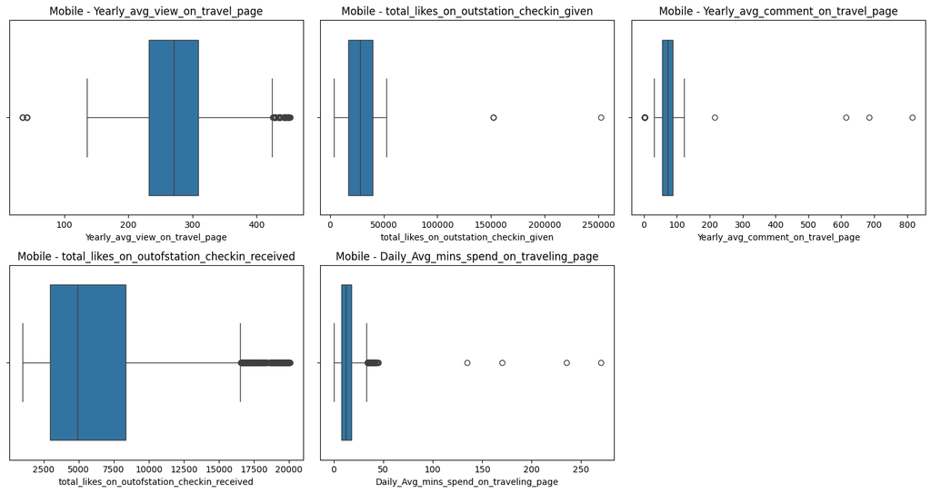

```python
plt.figure(figsize=(15, 8))
for i, col in enumerate(continuous_cols, 1):
    plt.subplot(2, 3, i)
    sns.boxplot(x=df_mobile[col])
    plt.title(f'Mobile - {col}')
plt.tight_layout()
plt.show()
```

**Observations:**

For mobile users, outliers are observed in engagement-related variables, indicating a small group of highly active users. These values represent valid customer behavior and were retained for modeling.

##### **Outlier Detection For Laptop Users**

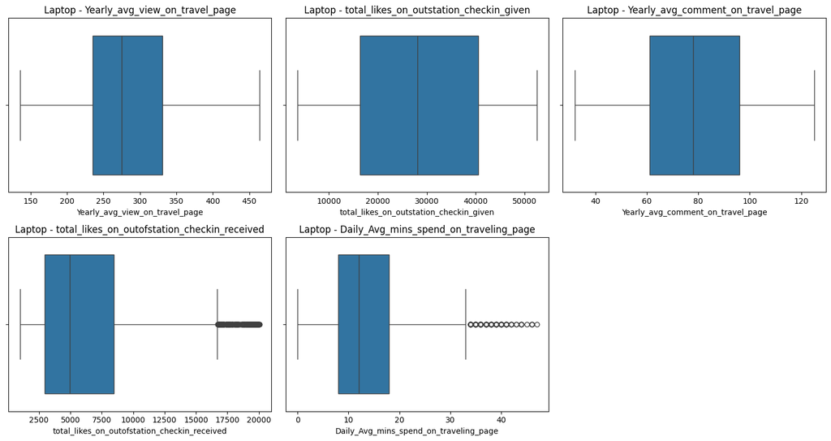

```python
plt.figure(figsize=(15, 8))
for i, col in enumerate(continuous_cols, 1):
    plt.subplot(2, 3, i)
    sns.boxplot(x=df_laptop[col])
    plt.title(f'Laptop - {col}')
plt.tight_layout()
plt.show()
```

**Observations:**

Laptop users show relatively wider spread in session duration and page views. The presence of extreme values reflects genuine high-intent behavior rather than noise.

##### **IQR Count Summary**

```python
def outlier_count_iqr(df, cols):
    for col in cols:
        Q1 = df[col].quantile(0.25)
        Q3 = df[col].quantile(0.75)
        IQR = Q3 - Q1
        lower = Q1 - 1.5 * IQR
        upper = Q3 + 1.5 * IQR
        count = df[(df[col] < lower) | (df[col] > upper)].shape[0]
        print(f"{col}: {count} outliers")

print("Mobile Outliers")
outlier_count_iqr(df_mobile, continuous_cols)

print("\nLaptop Outliers")
outlier_count_iqr(df_laptop, continuous_cols)
```

```
Mobile Outliers
Yearly_avg_view_on_travel_page: 132 outliers
total_likes_on_outstation_checkin_given: 4 outliers
Yearly_avg_comment_on_travel_page: 40 outliers
total_likes_on_outofstation_checkin_received: 489 outliers
Daily_Avg_mins_spend_on_traveling_page: 180 outliers

Laptop Outliers
Yearly_avg_view_on_travel_page: 0 outliers
total_likes_on_outstation_checkin_given: 0 outliers
Yearly_avg_comment_on_travel_page: 0 outliers
total_likes_on_outofstation_checkin_received: 396 outliers
Daily_Avg_mins_spend_on_traveling_page: 163 outliers
```

**Note:**

1. Outliers were not removed as they represent valid extreme customer behavior. Removing them could result in loss of important high-intent signals, especially for purchase prediction.
2. Discrete numerical variables such as Adult_flag, travelling_network_rating, yearly_avg_Outstation_checkins, and Taken_product were treated as categorical. Hence, boxplots and correlation-based outlier detection were not applied to them.

#### **Class Imbalance Handling**

```python
df_mobile['Taken_product'].value_counts(normalize=True)
```

| Taken_product | proportion |
| --- | --- |
| 0 | 0.845014 |
| 1 | 0.154986 |

**dtype:** float64

**Observations:**

The target variable exhibits moderate class imbalance, with approximately 84% non-purchasers and 15% purchasers. Since the minority class is adequately represented and reflects real-world customer behavior, no resampling techniques were applied. Model evaluation focuses on precision, recall, and F1-score to account for the imbalance.

```python
df_laptop['Taken_product'].value_counts(normalize=True)
```

| Taken_product | proportion |
| --- | --- |
| 0 | 0.829364 |
| 1 | 0.170636 |

**dtype:** float64

**Observations:**

### **Feature Engineering**

```python
df_mobile['working_flag'] = df_mobile['working_flag'].map({'Yes':1, 'No':0})
df_laptop['working_flag'] = df_laptop['working_flag'].map({'Yes':1, 'No':0})
```

```python
df_mobile['social_engagement_score'] = df_mobile['total_likes_on_outstation_checkin_given'] + df_mobile['total_likes_on_outofstation_checkin_received'] + df_mobile['yearly_avg_Outstation_checkins']
df_laptop['social_engagement_score'] = df_laptop['total_likes_on_outstation_checkin_given'] + df_laptop['total_likes_on_outofstation_checkin_received'] + df_laptop['yearly_avg_Outstation_checkins']
```

**Note:**

1. Combines multiple social interaction metrics (likes given, likes received, and outstation check-ins) into a single comprehensive engagement indicator.
2. Provides a holistic view of how socially active a user is on the travel platform instead of analyzing fragmented signals.
3. Helps identify highly engaged users who are more likely to respond to targeted travel advertisements.
4. Reduces dimensionality and potential multicollinearity among closely related social interaction variables.

```python
df_mobile['engagement_intensity'] = df_mobile['Yearly_avg_view_on_travel_page'] + df_mobile['Yearly_avg_comment_on_travel_page'] + df_mobile['Daily_Avg_mins_spend_on_traveling_page']
df_laptop['engagement_intensity'] = df_laptop['Yearly_avg_view_on_travel_page'] + df_laptop['Yearly_avg_comment_on_travel_page'] + df_laptop['Daily_Avg_mins_spend_on_traveling_page']
```

**Observations:**

1. Captures the overall depth of a user’s interaction with travel content by aggregating views, comments, and time spent on travel pages.
2. Reflects the user’s interest level across different stages of the digital engagement funnel.
3. More effective than individual metrics in identifying users with strong travel intent.
4. Supports better prediction of conversion behavior by summarizing engagement strength into one feature.

```python
df_mobile['recent_traveler_flag'] = (df_mobile['week_since_last_outstation_checkin'] <= 4).astype(int)
df_laptop['recent_traveler_flag'] = (df_laptop['week_since_last_outstation_checkin'] <= 4).astype(int)
```

**Note:**

1. Identifies users who have traveled recently, which is a strong indicator of current travel intent.
2. Converts a continuous recency variable into a business-friendly binary signal for easier interpretation.
3. Helps differentiate active travelers from dormant users in marketing analysis.
4. Enables targeted campaign strategies by focusing on users with recent travel activity.

#### **Replacing value in dataframe**

```python
df_mobile['member_in_family'] = df_mobile['member_in_family'].replace('Three', 3)
df_laptop['member_in_family'] = df_laptop['member_in_family'].replace('Three', 3)
```

#### **Dropping Unwanted Columns from mobile and laptop dataframe**

```python
df_mobile.drop(columns=['UserID', 'preferred_device', 'total_likes_on_outstation_checkin_given', 'total_likes_on_outofstation_checkin_received', 'yearly_avg_Outstation_checkins',
'Yearly_avg_view_on_travel_page', 'Yearly_avg_comment_on_travel_page', 'Daily_Avg_mins_spend_on_traveling_page', 'week_since_last_outstation_checkin', 'device_group'], inplace=True)


df_laptop.drop(columns=['UserID', 'preferred_device', 'total_likes_on_outstation_checkin_given', 'total_likes_on_outofstation_checkin_received', 'yearly_avg_Outstation_checkins',
'Yearly_avg_view_on_travel_page', 'Yearly_avg_comment_on_travel_page', 'Daily_Avg_mins_spend_on_traveling_page', 'week_since_last_outstation_checkin', 'device_group'], inplace=True)
```

#### **Columns to encode**

```python
cat_cols = [
    'preferred_location_type',
]
```

#### **One-Hot Encode**

```python
df_encode_m = pd.get_dummies(
    df_mobile,
    columns=cat_cols,
    drop_first=True
)

df_encode_l = pd.get_dummies(
    df_laptop,
    columns=cat_cols,
    drop_first=True
)
```

### **Preparing Data For Modeling**

#### **Train-Test Split**

**For Mobile**

```python
X_m = df_encode_m.drop('Taken_product', axis=1)
y_m = df_encode_m['Taken_product']

# this adds the constant term to the dataset
X_m = sm.add_constant(X_m)

X_m_train, X_m_test, y_m_train, y_m_test = train_test_split(
    X_m, y_m, test_size=0.2, random_state=42, stratify=y_m
)
```

**For Laptop**

```python
X_l = df_encode_l.drop('Taken_product', axis=1)
y_l = df_encode_l['Taken_product']

# this adds the constant term to the dataset
X_l = sm.add_constant(X_l)

X_l_train, X_l_test, y_l_train, y_l_test = train_test_split(
    X_l, y_l, test_size=0.2, random_state=42, stratify=y_l
)
```

**Scaling Only For Numeric Column**

```python
num_cols = ['member_in_family', 'montly_avg_comment_on_company_page', 'travelling_network_rating', 'social_engagement_score', 'engagement_intensity']
```

```python
scaler_m = StandardScaler()
X_m_train[num_cols] = scaler_m.fit_transform(X_m_train[num_cols])
X_m_test[num_cols] = scaler_m.transform(X_m_test[num_cols])

scaler_l = StandardScaler()
X_l_train[num_cols] = scaler_l.fit_transform(X_l_train[num_cols])
X_l_test[num_cols] = scaler_l.transform(X_l_test[num_cols])
```

**Scale fit Only on train data**

```python
scaler_m = StandardScaler()
X_m_train[num_cols] = scaler_m.fit_transform(X_m_train[num_cols])
X_m_test[num_cols] = scaler_m.transform(X_m_test[num_cols])

scaler_l = StandardScaler()
X_l_train[num_cols] = scaler_l.fit_transform(X_l_train[num_cols])
X_l_test[num_cols] = scaler_l.transform(X_l_test[num_cols])
```

## **Baseline Model Building**

### **Logistic Regression**

#### **For Mobile**

```python
lr_m = LogisticRegression(max_iter=1000, class_weight='balanced')
lr_m.fit(X_m_train, y_m_train)
```

```
LogisticRegression(class_weight='balanced', max_iter=1000)
```

```python
train_pred_lr_m = lr_m.predict(X_m_train)
test_pred_lr_m = lr_m.predict(X_m_test)
```

##### **Confusion Matrix and Performance Check of Training data - For Mobile**

```
              precision    recall  f1-score   support

           0       0.93      0.72      0.81      4244
           1       0.31      0.69      0.43       778

    accuracy                           0.71      5022
   macro avg       0.62      0.70      0.62      5022
weighted avg       0.83      0.71      0.75      5022
```

```
np.float64(0.766802793116064)
```

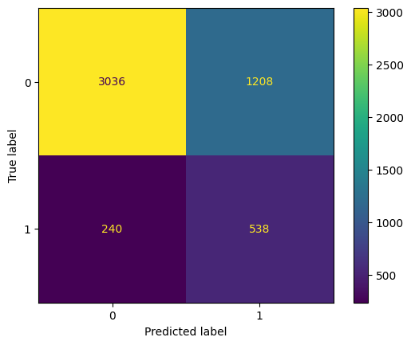

```python
cm_train_m = confusion_matrix(y_m_train, train_pred_lr_m)
ConfusionMatrixDisplay(cm_train_m).plot()

print(classification_report(y_m_train, train_pred_lr_m))
roc_auc_score(y_m_train, lr_m.predict_proba(X_m_train)[:,1])
```

**Observations:**

1. The model captures most mobile ticket buyers (Recall = 0.69), so fewer real buyers are missed.
2. Precision is low (0.31), meaning many users predicted as buyers do not actually purchase.
3. Confusion matrix shows 538 real buyers identified, but 1,208 non-buyers wrongly flagged as buyers.
4. F1-score = 0.43 indicates moderate balance between catching buyers and false alarms.
5. ROC-AUC ≈ 0.77, showing the model can fairly distinguish buyers vs non-buyers on mobile.

##### **Confusion Matrix and Performance Check of Testing data - For Mobile**

```
              precision    recall  f1-score   support

           0       0.93      0.72      0.81      1061
           1       0.32      0.72      0.44       195

    accuracy                           0.72      1256
   macro avg       0.63      0.72      0.63      1256
weighted avg       0.84      0.72      0.75      1256
```

```
np.float64(0.780434519925566)
```

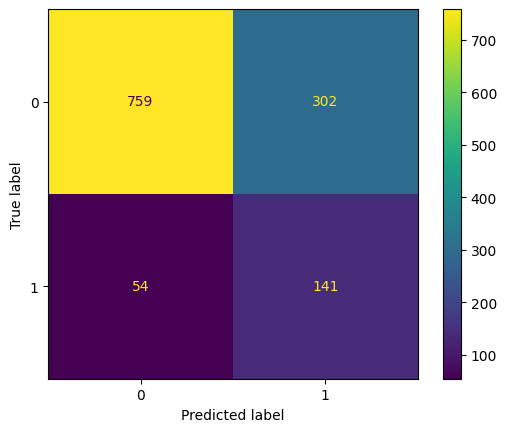

```python
cm_test_m = confusion_matrix(y_m_test, test_pred_lr_m)
ConfusionMatrixDisplay(cm_test_m).plot()

print(classification_report(y_m_test, test_pred_lr_m))
roc_auc_score(y_m_test, lr_m.predict_proba(X_m_test)[:,1])
```

**Observations:**

1. The model identifies most actual mobile ticket buyers (Recall = 0.72), so few buyers are missed.
2. Many users predicted as buyers do not actually buy (Precision = 0.32).
3. Confusion matrix shows 141 real buyers found, but 302 non-buyers wrongly flagged as buyers.
4. ROC-AUC ≈ 0.78, meaning the model is fairly good at separating buyers and non-buyers.
5. Mobile is useful for promotions and reminders, but predictions should not be treated as guaranteed purchases.

#### **For Laptop**

```python
lr_l = LogisticRegression(max_iter=2000, class_weight='balanced')
lr_l.fit(X_l_train, y_l_train)
```

```
LogisticRegression(class_weight='balanced', max_iter=2000)
```

```python
train_pred_lr_l = lr_l.predict(X_l_train)
test_pred_lr_l = lr_l.predict(X_l_test)
```

##### **Confusion Matrix and Performance Check of Training data - For Laptop**

```
              precision    recall  f1-score   support

           0       0.92      0.71      0.80      3538
           1       0.33      0.69      0.45       728

    accuracy                           0.71      4266
   macro avg       0.62      0.70      0.62      4266
weighted avg       0.82      0.71      0.74      4266
```

```
np.float64(0.7634124637375062)
```

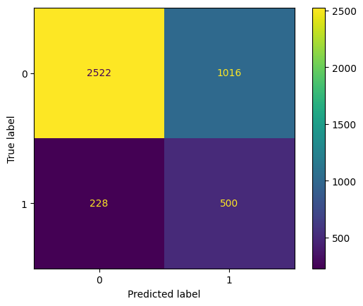

```python
cm_l = confusion_matrix(y_l_train, train_pred_lr_l)
ConfusionMatrixDisplay(cm_l).plot()

print(classification_report(y_l_train,train_pred_lr_l))
roc_auc_score(y_l_train, lr_l.predict_proba(X_l_train)[:,1])
```

**Observations:**

1. The model identifies most laptop ticket buyers (Recall = 0.69), so many real buyers are captured.
2. Precision is low (0.33), meaning several users predicted as buyers do not actually purchase.
3. Confusion matrix shows 500 real buyers correctly identified, but 1,016 non-buyers wrongly predicted as buyers.
4. F1-score = 0.45 indicates moderate performance in balancing buyer detection and false predictions.
5. ROC-AUC ≈ 0.76, showing the model can reasonably distinguish buyers from non-buyers on laptop.

##### **Confusion Matrix and Performance Check of Testing data - For Laptop**

```
              precision    recall  f1-score   support

           0       0.92      0.73      0.81       885
           1       0.34      0.70      0.46       182

    accuracy                           0.72      1067
   macro avg       0.63      0.71      0.64      1067
weighted avg       0.82      0.72      0.75      1067
```

```
np.float64(0.7710188116967778)
```

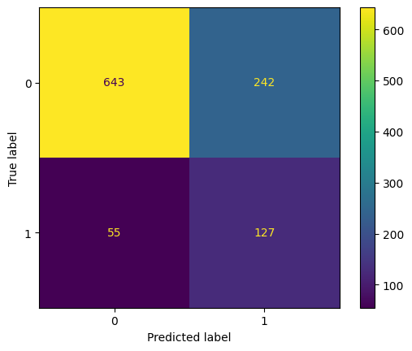

```python
cm_test_l = confusion_matrix(y_l_test, test_pred_lr_l)
ConfusionMatrixDisplay(cm_test_l).plot()

print(classification_report(y_l_test,test_pred_lr_l))
roc_auc_score(y_l_test, lr_l.predict_proba(X_l_test)[:,1])
```

**Observations:**

1. The model identifies most real laptop ticket buyers (Recall = 0.70), so fewer buyers are missed.
2. Precision is low (0.34), meaning many users predicted as buyers do not actually purchase.
3. Confusion matrix shows 127 real buyers correctly identified, but 242 non-buyers wrongly flagged as buyers.
4. F1-score = 0.46 indicates moderate and balanced performance.
5. ROC-AUC ≈ 0.77, showing the model can fairly distinguish buyers from non-buyers on laptop.

## **Advance Mobel Building with Hyperparameter Tuning**

```python
# defining a function to compute different metrics to check performance of a classification model built using sklearn
def model_performance_classification_sklearn(model, predictors, target):
    """
    Function to compute different metrics to check classification model performance

    model: classifier
    predictors: independent variables
    target: dependent variable
    """

    # predicting using the independent variables
    pred = model.predict(predictors)

    # Probabilities for ROC-AUC
    prob = model.predict_proba(predictors)[:, 1]


    acc = accuracy_score(target, pred)  # to compute Accuracy
    recall = recall_score(target, pred)  # to compute Recall
    precision = precision_score(target, pred)  # to compute Precision
    f1 = f1_score(target, pred)  # to compute F1-score
    roc_auc = roc_auc_score(target, prob)

    # creating a dataframe of metrics
    df_perf = pd.DataFrame(
        {
            "Accuracy": acc,
            "Recall": recall,
            "Precision": precision,
            "F1": f1,
            "ROC_AUC": roc_auc,
        },
        index=[0],
    )

    return df_perf
```

```python
def confusion_matrix_sklearn(model, predictors, target):
    """
    To plot the confusion_matrix with percentages

    model: classifier
    predictors: independent variables
    target: dependent variable
    """
    y_pred = model.predict(predictors)
    cm = confusion_matrix(target, y_pred)
    labels = np.asarray(
        [
            ["{0:0.0f}".format(item) + "\n{0:.2%}".format(item / cm.flatten().sum())]
            for item in cm.flatten()
        ]
    ).reshape(2, 2)

    plt.figure(figsize=(6, 4))
    sns.heatmap(cm, annot=labels, fmt="")
    plt.ylabel("True label")
    plt.xlabel("Predicted label")
```

### **Decision Tree Model**

#### **For Mobile**

```python
dtree_m =DecisionTreeClassifier(criterion="gini", random_state=1,)
dtree_m.fit(X_m_train, y_m_train)
```

```
DecisionTreeClassifier(random_state=1)
```

##### **Confusion Matrix and Performance Check of Testing data - For Mobile**

```
Testing performance
    Accuracy    Recall  Precision        F1   ROC_AUC
0  0.928344  0.733333   0.790055  0.760638  0.848759
```

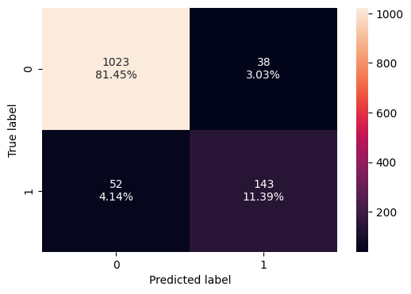

```python
#create a confusion matrix of the classifier's performance on the testing data
confusion_matrix_sklearn(dtree_m, X_m_test, y_m_test)

dtree_model_test_perf_m= model_performance_classification_sklearn(dtree_m, X_m_test, y_m_test)
print("Testing performance \n",dtree_model_test_perf_m)
```

**Observations:**

1. The model performs very well overall (Accuracy ≈ 0.93), showing strong prediction quality.
2. High precision (≈ 0.79) means most users predicted as buyers actually buy tickets.
3. Recall ≈ 0.73 indicates the model captures most real mobile buyers, with few missed.
4. F1-score ≈ 0.76 shows a good balance between precision and recall.
5. ROC-AUC ≈ 0.85, meaning the Decision Tree clearly separates buyers from non-buyers.

##### **Confusion Matrix and Performance Check of Training data - For Mobile**

```
Training performance
    Accuracy  Recall  Precision   F1  ROC_AUC
0       1.0     1.0        1.0  1.0      1.0
```

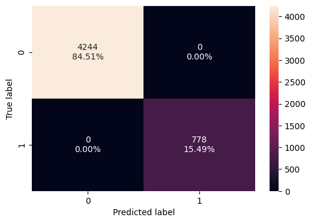

```python
#create a confusion matrix of the classifier's performance on the training data
confusion_matrix_sklearn(dtree_m, X_m_train, y_m_train)

dtree_model_train_perf_m = model_performance_classification_sklearn(dtree_m, X_m_train, y_m_train)
print("Training performance \n",dtree_model_train_perf_m)
```

**Observations:**

1. The model shows perfect performance on training data (Accuracy, Precision, Recall, F1, ROC-AUC = 1.0).
2. Confusion matrix shows no misclassifications – all buyers and non-buyers are predicted correctly.
3. This indicates overfitting, not real-world perfection.
4. Such perfect scores mean the model has memorized training data.
5. Predictions on new mobile users may be less reliable than training results suggest.

##### **Decision Tree with Hyperparameter Tuning - For Mobile**

```python
# choosing type of classifier
tuning_decision_tree_m =DecisionTreeClassifier(random_state=1)

# form grid of parameters to search in
grid_para ={
    "class_weight": ["balanced", None],
    "max_depth": np.arange(2, 20, 2),
    "max_leaf_nodes": np.arange(2, 20, 2),
    "min_samples_split": [50, 100, 150, 200],
    "min_impurity_decrease": [0.0001, 0.001, 0.01], }

# setting type of score used to evaluate performance search
scorer =make_scorer(f1_score)

# running GridSearch
grid_obj = GridSearchCV(tuning_decision_tree_m, grid_para, scoring=scorer, cv =5)
grid_obj =grid_obj.fit(X_m_train, y_m_train)

# setting classifer to best combination of parameters
tuning_decision_tree_m =grid_obj.best_estimator_

# fitting best decision tree to training data
tuning_decision_tree_m.fit(X_m_train, y_m_train)
```

```
DecisionTreeClassifier(class_weight='balanced', max_depth=np.int64(8),
                       max_leaf_nodes=np.int64(16),
                       min_impurity_decrease=0.0001, min_samples_split=50,
                       random_state=1)
```

##### **Confusion Matrix and Performance Check After Tuning - For Mobile**

```
Testing performance
    Accuracy    Recall  Precision        F1   ROC_AUC
0  0.790605  0.625641   0.391026  0.481262  0.787612
```

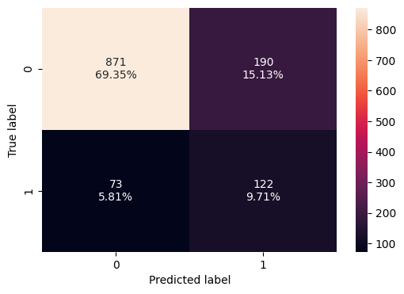

```python
#create a confusion matrix of the classifier's performance on the testing data
confusion_matrix_sklearn(tuning_decision_tree_m, X_m_test,y_m_test)

tuned_dtree_model_test_perf_m = model_performance_classification_sklearn(tuning_decision_tree_m, X_m_test, y_m_test)
print("Testing performance \n",tuned_dtree_model_test_perf_m)
```

**Observations:**

1. ROC-AUC ≈ 0.79, showing the model can fairly distinguish buyers from non-buyers.
2. Recall ≈ 0.63, meaning the model catches most real mobile buyers, but some are still missed.
3. Precision ≈ 0.39, so several users predicted as buyers do not actually buy.
4. Confusion matrix shows 122 real buyers correctly identified, while 190 non-buyers are wrongly flagged.
5. F1-score ≈ 0.48, indicating moderate and balanced performance.

```
Training performance
    Accuracy    Recall  Precision       F1   ROC_AUC
0  0.793907  0.632391   0.396454  0.48737  0.783525
```

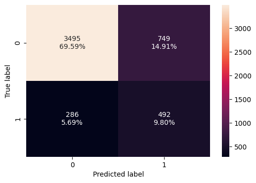

```python
#create a confusion matrix of the classifier's performance on the training data
confusion_matrix_sklearn(tuning_decision_tree_m, X_m_train,y_m_train)

tuned_dtree_model_train_perf_m = model_performance_classification_sklearn(tuning_decision_tree_m, X_m_train, y_m_train)
print("Training performance \n",tuned_dtree_model_train_perf_m)
```

**Observations:**

1. ROC-AUC ≈ 0.78, consistent with test performance (good sign).
2. Recall ≈ 0.63, showing the model learns buyer patterns reasonably well.
3. Precision ≈ 0.40, meaning false buyer predictions still exist.
4. Confusion matrix shows 492 real buyers identified, but 749 non-buyers wrongly predicted as buyers.
5. F1-score ≈ 0.49, indicating stable but moderate performance.

#### **For Laptop**

```python
dtree_l = DecisionTreeClassifier(criterion="gini", random_state=1,)
dtree_l.fit(X_l_train, y_l_train)
```

```
DecisionTreeClassifier(random_state=1)
```

##### **Confusion Matrix and Performance Check of Testing data - For Laptop**

```
Testing performance
    Accuracy    Recall  Precision        F1   ROC_AUC
0  0.938144  0.835165   0.808511  0.821622  0.897243
```

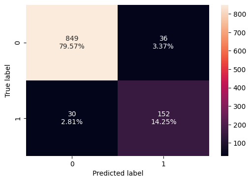

```python
#create a confusion matrix of the classifier's performance on the testing data
confusion_matrix_sklearn(dtree_l, X_l_test, y_l_test)

dtree_model_test_perf_l = model_performance_classification_sklearn(dtree_l, X_l_test, y_l_test)
print("Testing performance \n",dtree_model_test_perf_l)
```

**Observations:**

1. Very strong performance with Accuracy ≈ 0.94.
2. High Precision ≈ 0.81, meaning most users predicted as buyers actually buy tickets.
3. High Recall ≈ 0.84, so the model captures most real laptop buyers.
4. Confusion matrix shows 152 real buyers correctly identified, with very few buyers missed (30).
5. ROC-AUC ≈ 0.90, indicating excellent separation between buyers and non-buyers.

##### **Confusion Matrix and Performance Check of Training data - For Laptop**

```python
#create a confusion matrix of the classifier's performance on the training data
confusion_matrix_sklearn(dtree_l, X_l_train, y_l_train)

dtree_model_train_perf_l = model_performance_classification_sklearn(dtree_l, X_l_train, y_l_train)
print("Training performance \n",dtree_model_train_perf_l)
```

[output not shown]

```
Training performance
    Accuracy  Recall  Precision   F1  ROC_AUC
0       1.0     1.0        1.0  1.0      1.0
```

**Observations:**

##### **Decision Tree with Hyperparameter Tuning - For Laptop**

```python
# choosing type of classifier
tuning_decision_tree_l =DecisionTreeClassifier(random_state=1)

# form grid of parameters to search in
grid_para ={
    "class_weight": ["balanced", None],
    "max_depth": np.arange(2, 20, 2),
    "max_leaf_nodes": np.arange(2, 20, 2),
    "min_samples_split": [50, 100, 150, 200],
    "min_impurity_decrease": [0.0001, 0.001, 0.01], }

# setting type of score used to evaluate performance search
scorer =make_scorer(f1_score)

# running GridSearch
grid_obj = GridSearchCV(tuning_decision_tree_m, grid_para, scoring=scorer, cv =5)
grid_obj =grid_obj.fit(X_l_train, y_l_train)

# setting classifer to best combination of parameters
tuning_decision_tree_l =grid_obj.best_estimator_

# fitting best decision tree to training data
tuning_decision_tree_l.fit(X_l_train, y_l_train)
```

```
DecisionTreeClassifier(class_weight='balanced', max_depth=np.int64(8),
                       max_leaf_nodes=np.int64(18),
                       min_impurity_decrease=0.0001, min_samples_split=50,
                       random_state=1)
```

##### **Confusion Matrix and Performace Check After Tuning - For Laptop**

```
Testing performance
    Accuracy    Recall  Precision        F1   ROC_AUC
0  0.669166  0.785714    0.31291  0.447574  0.758872
```

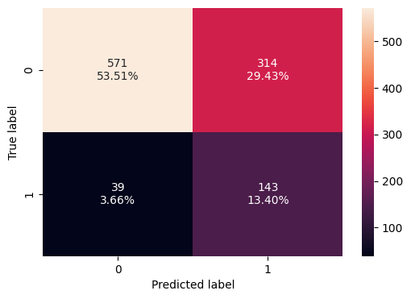

```python
#create a confusion matrix of the classifier's performance on the testing data
confusion_matrix_sklearn(tuning_decision_tree_l, X_l_test,y_l_test)

tuned_dtree_model_test_perf_l = model_performance_classification_sklearn(tuning_decision_tree_l, X_l_test, y_l_test)
print("Testing performance \n",tuned_dtree_model_test_perf_l)
```

**Observations:**

1. Moderate overall performance (Accuracy ≈ 0.67).
2. High Recall ≈ 0.79, so the model catches most real laptop buyers.
3. Low Precision ≈ 0.31, meaning many predicted buyers do not actually buy.
4. Confusion matrix shows 143 real buyers identified, but 314 non-buyers wrongly predicted as buyers.
5. ROC-AUC ≈ 0.76, indicating fair buyer vs non-buyer separation.

```
Training performance
    Accuracy   Recall  Precision        F1   ROC_AUC
0  0.686357  0.81044   0.329609  0.468626  0.797004
```

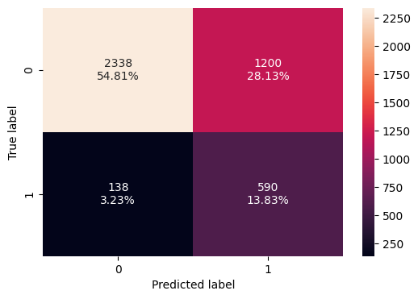

```python
#create a confusion matrix of the classifier's performance on the training data
confusion_matrix_sklearn(tuning_decision_tree_l, X_l_train,y_l_train)

tuned_dtree_model_train_perf_l = model_performance_classification_sklearn(tuning_decision_tree_l, X_l_train, y_l_train)
print("Training performance \n",tuned_dtree_model_train_perf_l)
```

**Observations:**

1. Similar performance to test data (Accuracy ≈ 0.69), showing reduced overfitting.
2. Recall ≈ 0.81, consistently capturing laptop buyers.
3. Precision ≈ 0.33, false buyer predictions remain high.
4. ROC-AUC ≈ 0.80, slightly better discrimination on training data.
5. F1-score ≈ 0.47, showing moderate, stable balance.

### **Bagging Classifier**

#### **For Mobile**

```python
# using function BaggingClassifier from sklearn to build model
bagging_m =BaggingClassifier(random_state=1)
bagging_m.fit(X_m_train, y_m_train)
```

```
BaggingClassifier(random_state=1)
```

##### **Confusion Matrix and Performance Check of Testing data - For Mobile**

```
Testing performance
    Accuracy    Recall  Precision       F1   ROC_AUC
0  0.948248  0.702564   0.951389  0.80826  0.963423
```

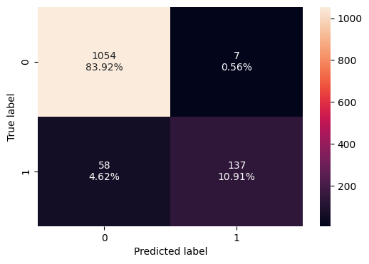

```python
#create a confusion matrix of the classifier's performance on the testing data
confusion_matrix_sklearn(bagging_m, X_m_test, y_m_test)

bagging_model_test_perf_m= model_performance_classification_sklearn(bagging_m, X_m_test, y_m_test)
print("Testing performance \n",bagging_model_test_perf_m)
```

**Observations:**

1. Excellent overall performance (Accuracy ≈ 0.95).
2. Very high Precision ≈ 0.95, meaning almost all users predicted as buyers actually buy tickets.
3. Good Recall ≈ 0.70, so most real buyers are captured, with some still missed.
4. Confusion matrix shows 137 real buyers correctly identified and very few false buyer predictions (only 7).
5. ROC-AUC ≈ 0.96, indicating outstanding separation between buyers and non-buyers.

##### **Confusion Matrix and Performace Check of Training data - For Mobile**

```
Training performance
    Accuracy    Recall  Precision        F1   ROC_AUC
0  0.995221  0.970437   0.998677  0.984355  0.999959
```

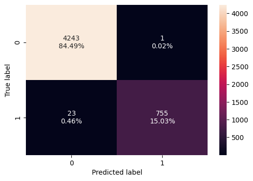

```python
#create a confusion matrix of the classifier's performance on the training data
confusion_matrix_sklearn(bagging_m, X_m_train, y_m_train)

bagging_model_train_perf_m = model_performance_classification_sklearn(bagging_m, X_m_train, y_m_train)
print("Training performance \n",bagging_model_train_perf_m)
```

**Observations:**

1. Near-perfect performance (Accuracy ≈ 0.995, F1 ≈ 0.98).
2. Confusion matrix shows almost no misclassifications.
3. ROC-AUC ≈ 1.00, showing extremely strong learning.
4. Indicates very strong fit, but test performance confirms it generalizes well.
5. Train results support the robustness of the model.

##### **Bagging Classifier With Hyperparameter Tuning - For Mobile**

```python
# choosing type of classifier
tuning_bagging_m =BaggingClassifier(random_state=1)

# form grid of parameters to search in
grid_para ={
    "max_samples": [0.7, 0.8, 0.9, 1.0],
    "max_features": [0.7, 0.8, 0.9, 1.0],
    "n_estimators": np.arange(50, 100, 10), }

# setting type of score used to evaluate performance search
scorer = make_scorer(f1_score)

# runing GridSearch
grid_obj =GridSearchCV(tuning_bagging_m, grid_para, scoring=scorer, cv=5)
grid_obj =grid_obj.fit(X_m_train, y_m_train)

# setting classifer to best combination of parameters
tuning_bagging_m =grid_obj.best_estimator_

# fitting best decision tree to training data
tuning_bagging_m.fit(X_m_train, y_m_train)
BaggingClassifier(max_features=0.7, max_samples=0.7, n_estimators=60, random_state=1)
```

```
BaggingClassifier(max_features=0.7, max_samples=0.7, n_estimators=60,
                  random_state=1)
```

##### **Confusion Matrix and Performace Check After Tuning - For Mobile**

```
Testing performance
    Accuracy    Recall  Precision        F1   ROC_AUC
0  0.960987  0.769231   0.974026  0.859599  0.988407
```

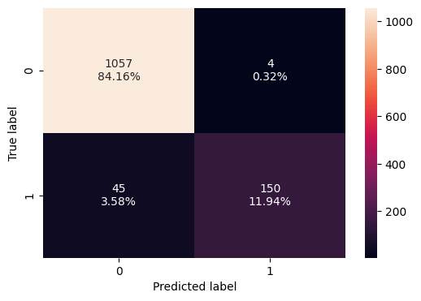

```python
#create a confusion matrix of the classifier's performance on the testing data
confusion_matrix_sklearn(tuning_bagging_m, X_m_test,y_m_test)

tuned_bagging_model_test_perf_m = model_performance_classification_sklearn(tuning_bagging_m, X_m_test, y_m_test)
print("Testing performance \n",tuned_bagging_model_test_perf_m)
```

**Observations:**

1. Excellent overall performance (Accuracy ≈ 0.96).
2. Very high Precision ≈ 0.97, meaning almost all users predicted as buyers actually purchase tickets.
3. Good Recall ≈ 0.77, so most real mobile buyers are captured, with a few missed.
4. Confusion matrix shows 150 real buyers correctly identified and only 4 non-buyers wrongly predicted as buyers.
5. ROC-AUC ≈ 0.99, indicating outstanding ability to separate buyers from non-buyers.

```
Training performance
    Accuracy  Recall  Precision   F1  ROC_AUC
0       1.0     1.0        1.0  1.0      1.0
```

[figure not shown]

```python
#create a confusion matrix of the classifier's performance on the training data
confusion_matrix_sklearn(tuning_decision_tree_m, X_m_train,y_m_train)

tuned_bagging_model_train_perf_m = model_performance_classification_sklearn(tuning_bagging_m, X_m_train, y_m_train)
print("Training performance \n",tuned_bagging_model_train_perf_m)
```

**Observations:**